# Exploring Pacific giant salamander abundance and weight in relationship to forest and channel type in Mack Creek, Oregon (1993 - 2017).

ESM 206 Assignment 5

Kaitlyn Lanfield and Ashley Stroud

Due: Decemeber 4, 2019

### Introduction

When considering take of natural resources, it is important to consider the effects this take can have on its associated ecosystem. Studies have shown that clear cutting for logging operations can have both positive and negative impacts on the habitat and the species that live there, and these impacts can change with time (Murphy 1981). The HJ Andrews Experimental Forest is a long term ecological research (LTER) site that has two sections of forest, a clear cut section (ca. 1963) and a 500 year old coniferous forest, allowing researchers the opportunity to study both ecosystem systems compareatively over time. Here we look at the Pacific giant salamander (*Dicamptodon tenebrosus*) (Figure 1.), an inhabitant of this area, and a species whose larval stage was shown to be negatively affected by logging (Corn 1989). Using the HJ Andrews Experimental Forest LTER survey data, we investigate if there is a relationship to the type of forest (clear cut or old growth) the Pacific giant salamanders reside in, to their population abundance, weight and channel preference.

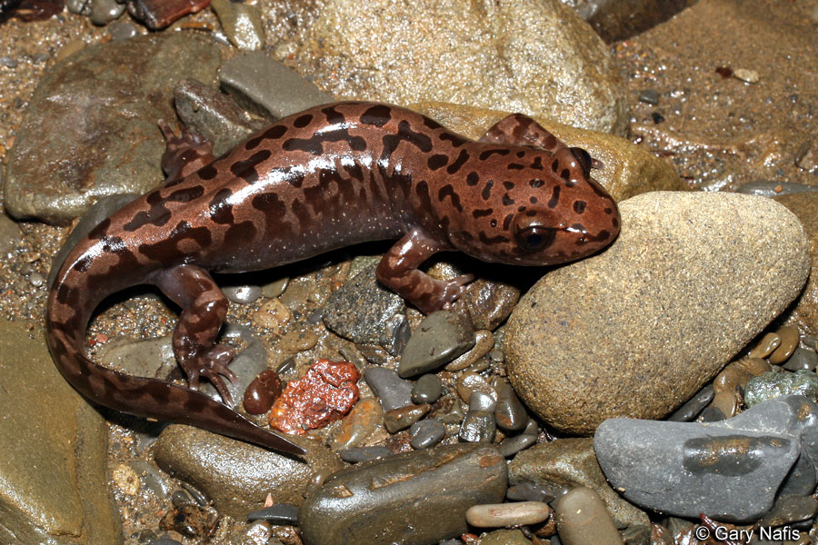

###### *Figure 1.* *Pacific giant salamander(Dicamptodon tenebrosus). Photo credit: Gary Nafis.*

### Data and Methods

Data on Pacific giant salamanders was collected from 1993 - 2017 in Mack Creek of H.J Andrews Experimental Forest, Oregon (Figure 2.). Samples were collected in forests that were subjected to clearcutting in 1963 (clear cut) or in a 500 year old coniferous forest (old growth). Salamanders were collected via electrofishing in different channels (pools, cascades, or side - channels) and weighed to the nearest 0.01 grams. For more detailed information, refer to the [metadata](https://portal.lternet.edu/nis/mapbrowse?packageid=knb-lter-and.4027.12) (Gregory S. V. 2016). We compared salamander abundances in 2017 between channel types in clear cut and growth forests using a chi-squared test. Mean salamander weights between clear cut and old growth forests were compared with a Welch two-sample t-test (α = 0.05). In addition, we used an ANOVA with post-hoc Tukey HSD to compare mean salamander weights between channel types. All analyses and figures were prepared using R software version 3.6.1.

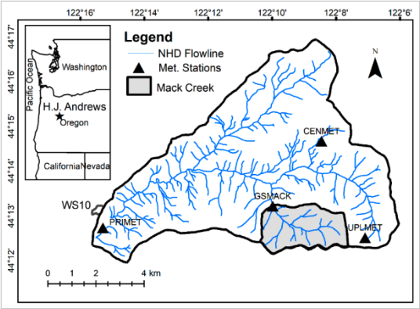

###### *Figure 2.* *Map of the H.J Andrews Experimental Forest, Oregon. Location of Mack Creek is shaded in gray. (Mosquera, Segura, & Crespo, 2018)*

### Results

#### A: Changes in annual salamander abundance in old growth and clear cut sections of Mack Creek.

Abundance in pacific salamanders has increased overall in both clear cut and old growth forests from 1993 to 2017, rising by 198% and 154% respectively. The two salamander populations appear to follow a similar pattern of incline and decline in population abundance throughout the study. The salamanders in old growth forests generally had higher counts compared to those in clear cut forests, until 2014 (Figure 3.).

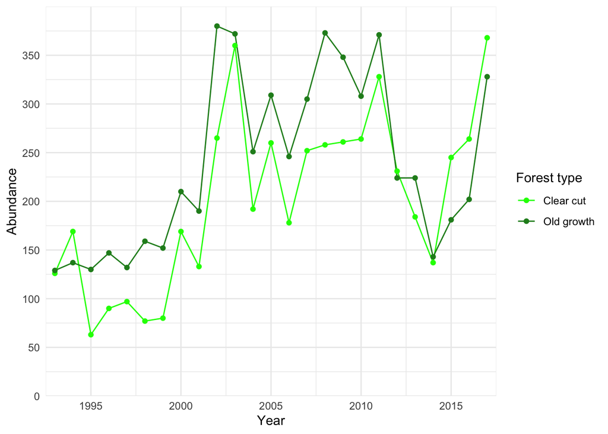

*Figure 3.* *Annual pacific salamander counts in old growth and clear cut sections of Mack Creek (1993 - 2017).*

#### B: Abundance of Pacific giant salamanders across channel and forest type in 2017

There is no significant effect of forest type (clear cut/old growth) on where in the channel (cascade/pool/side-channel) pacific salamanders are found ($\chi$<sup>2</sup>(2) = 5.54, *p* = 0.06). The percentage of salamanders found in cascades and side-channels differed by less than 5% between clear cut and old growth forests. Percentages of salamanders found in pools differed slightly more, but still by less than 10% (Table 1.).

*Table 1.* *Counts of Pacific giant salamanders in clear cut and old growth forests across channel types in 2017. Percentages of salamanders found in each channel type (cascade, pool, side-channel) are expressed in relation to the total number of salamanders found in each forest type (clear cut, old growth).*

| Channel type Forest type | Channel type Cascade | Channel type Pool | Channel type Side-channel |
| --- | --- | --- | --- |
| Clear cut | 247 (67.1%) | 31 (8.4%) | 90 (24.5%) |
| Old growth | 201 (62.8%) | 45 (14.1%) | 74 (23.1%) |

#### C: Mean weights of Pacific giant salamanders between forest types in 2017

Weights were compared of pacific giant salamanders in old growth forests to those in clear cut forests in 2017 only. There was not a significant difference in weights of salamanders between the two forest types (Welch Two Sample t-test, t = 1.67, df = 692.79, p = 0.096). Mean weights differed by 16.7%, with a negligible effect size (Cohen’s d = (0.13)).

#### D: Mean weights of Pacific giant salamander by channel type in 2017.

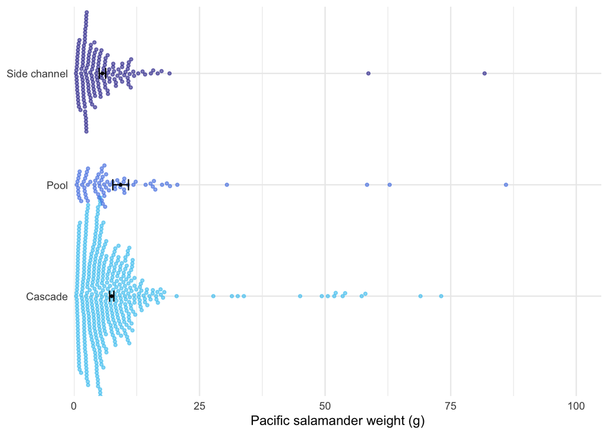

*Figure 4.* *Pacific giant salamander weights across channel types ( side-channel, pool, cascade). Mean salamander weights per channel type are depicted by black dots with error-bars representing standard error.*

A significant difference was detected in mean salamander weights (g) by channel type (one-way ANOVA, F(2, 684) = 4.22, *p* = 0.015). A post-hoc analysis was performed using Tukey’s HSD and a signifiant difference was detected between side-channel and pool (*p* = 0.017), differing by around 48% with a small effect size (Cohen’s d = (0.35)). No significant difference was detected between the other pariwise combinations in the Tukey’s HSD post hoc analysis: cascade and side-channels had a mean difference of 27.8% (*p* = 0.084) with a small effect size (Cohen’s d = (0.21)), and cascade and pool had a mean difference of 21.1% (*p* = 0.286) with a negligible effect size (Cohen’s d = (-0.18)).

While comparisons of means was used for this analysis, it is important to note that this might not be the best method for analysis, as a visual investigation indicates that this data contains many outliers, is heavily skewed and varies in samples size (Figure 4.). For further investigation, we recommend a comparisons of median values, a measure of central tendency that will not be biased by skew and outliers.

#### Summary

- From 1993 - 2017, Pacific giant salamander abundances between clear cut and old growth forests followed similar trends, but overall were less in clear cut forests (Figure 3.)
- Abundances of salamanders in cascades, pools, and side - channels were not significantly effected by the forest type (clear cut or old growth) they were found in (Table 1.)
- Average salamander weights did not significantly differ between forest types (Results C.)
- Average salamander weights differed significantly between side-channels and pools (Figure 4.)

#### References

**Corn, P. S. and Bury, R. B. (1989).** Logging in Western Oregon: responses of headwater habitats and stream amphibians. Forest Ecology and Management, 29, 39-57.

**Gregory S. V. (2016).** Aquatic Vertebrate Population Study in Mack Creek, Andrews Experimental Forest, 1987 to present. Environmental Data Initiative. https://doi.org/10.6073/pasta/5de64af9c11579266ef20da2ff32f702. Dataset accessed 11/19/2019.

**Mosquera, G. M., Segura, C., & Crespo, P. (2018).** Flow partitioning modelling using high-resolution isotopic and electrical conductivity data. Water (Switzerland), 10(7), 1–23. https://doi.org/10.3390/w10070904

**Murphy, M. L. and Hall, J. D. (1981).** Varied effects of clear cut logging on predators and their habitat in small streams of the Cascade Mountains, Oregon. Canadian Journal of Fisheries and Aquatic Science, 38, 137-145.